# Bellabeat Case Study

Adam Tuor

2023-07-20

## 1. Summary

Bellabeat is a high-tech manufacturer of health-focused products for women. They currently offer an app(Bellabeat app),wellness tracker(Leaf),watch(Time), water bottle(Spring), and a subscription for personalized guidance on the metrics each device tracks. The goal of these products is to inspire and empower women with knowledge about their own health and habits.

The primary focus of this case study is analyzing smart device fitness data to identify trends which can then be used to make recommendations for Bellabeat’s marketing strategy. This will ultimately lead to new growth opportunities for the company.

As all of the data we have is quantitative, we will focus our recommendations on the Bellabeat app, which houses all of the recorded data. The app tracks health data related to activity, sleep, stress, menstrual cycle, and mindfulness habits.

## 2. Ask Phase

**2.1 Business Task:**

- Identify patterns and trends present in the way consumers use non-Bellabeat smart devices to drive insights into how Bellabeat can reach these consumer segments with their marketing strategy.

**2.2 Stakeholders:**

- Urška Sršen: Bellabeat’s cofounder and Chief Creative Officer
- Sando Mur: Bellabeat’s cofounder and key member of the Bellabeat executive team
- Bellabeat marketing analytics team

## 3. Prepare Phase

**3.1 Dataset:**

The data used for this case study can be found on [Kaggle](https://www.kaggle.com/datasets/arashnic/fitbit). The data contains usage data for 33 FitBit users including activity levels, steps, calories and sleep.

**3.2 Limitations:**

The dataset is limited in generating insights due to the small sample size of 33 participants. In addition, due to either device differences or lack of participation, many of the different csv files have less than 33 participants. For this reason I will focus on using the “dailyActivity_merged”, “hourlySteps_merged”, and “hourlyIntensities_merged” datasets for this case study.

## 4. Process Phase

**4.1 Loading libraries**

- tidyverse

```r
library(tidyverse)
```

**4.2 Import datasets**

- dailyActivity_merged
- hourlySteps_merged
- hourlyIntensities_merged

```r
daily_activity<-read.csv("dailyActivity_merged.csv")
hourly_steps <-read.csv("hourlySteps_merged.csv")
hourly_intensity<-read.csv("hourlyIntensities_merged.csv")
```

**4.3 Checking structure**

```r
str(daily_activity)
```

```
## 'data.frame':    940 obs. of  15 variables:
##  $ Id                      : num  1.5e+09 1.5e+09 1.5e+09 1.5e+09 1.5e+09 ...
##  $ ActivityDate            : chr  "4/12/2016" "4/13/2016" "4/14/2016" "4/15/2016" ...
##  $ TotalSteps              : int  13162 10735 10460 9762 12669 9705 13019 15506 10544 9819 ...
##  $ TotalDistance           : num  8.5 6.97 6.74 6.28 8.16 ...
##  $ TrackerDistance         : num  8.5 6.97 6.74 6.28 8.16 ...
##  $ LoggedActivitiesDistance: num  0 0 0 0 0 0 0 0 0 0 ...
##  $ VeryActiveDistance      : num  1.88 1.57 2.44 2.14 2.71 ...
##  $ ModeratelyActiveDistance: num  0.55 0.69 0.4 1.26 0.41 ...
##  $ LightActiveDistance     : num  6.06 4.71 3.91 2.83 5.04 ...
##  $ SedentaryActiveDistance : num  0 0 0 0 0 0 0 0 0 0 ...
##  $ VeryActiveMinutes       : int  25 21 30 29 36 38 42 50 28 19 ...
##  $ FairlyActiveMinutes     : int  13 19 11 34 10 20 16 31 12 8 ...
##  $ LightlyActiveMinutes    : int  328 217 181 209 221 164 233 264 205 211 ...
##  $ SedentaryMinutes        : int  728 776 1218 726 773 539 1149 775 818 838 ...
##  $ Calories                : int  1985 1797 1776 1745 1863 1728 1921 2035 1786 1775 ...
```

```r
str(hourly_intensity)
```

```
## 'data.frame':    22099 obs. of  4 variables:
##  $ Id              : num  1.5e+09 1.5e+09 1.5e+09 1.5e+09 1.5e+09 ...
##  $ ActivityHour    : chr  "4/12/2016 12:00:00 AM" "4/12/2016 1:00:00 AM" "4/12/2016 2:00:00 AM" "4/12/2016 3:00:00 AM" ...
##  $ TotalIntensity  : int  20 8 7 0 0 0 0 0 13 30 ...
##  $ AverageIntensity: num  0.333 0.133 0.117 0 0 ...
```

```r
str(hourly_steps)
```

```
## 'data.frame':    22099 obs. of  3 variables:
##  $ Id          : num  1.5e+09 1.5e+09 1.5e+09 1.5e+09 1.5e+09 ...
##  $ ActivityHour: chr  "4/12/2016 12:00:00 AM" "4/12/2016 1:00:00 AM" "4/12/2016 2:00:00 AM" "4/12/2016 3:00:00 AM" ...
##  $ StepTotal   : int  373 160 151 0 0 0 0 0 250 1864 ...
```

The date fields will need to be fixed, but first let’s double check that our counts are correct and there are no duplicates.

```r
n_distinct(daily_activity$Id)
```

```
## [1] 33
```

```r
n_distinct(hourly_intensity$Id)
```

```
## [1] 33
```

```r
n_distinct(hourly_steps$Id)
```

```
## [1] 33
```

Let’s make sure there are no duplicates.

```r
sum(duplicated(daily_activity))
```

```
## [1] 0
```

```r
sum(duplicated(hourly_steps))
```

```
## [1] 0
```

```r
sum(duplicated(hourly_intensity))
```

```
## [1] 0
```

**4.4 Fixing date columns**

The columns containing dates were of type string, so we’re going to start by converting them to date. For the hourly data, we’re going to convert to datetime and then split them into their own columns.

```r
daily_activity$ActivityDate <- mdy(daily_activity$ActivityDate)
hourly_intensity$ActivityHour<-as.POSIXct(hourly_intensity$ActivityHour, format = "%m/%d/%Y %I:%M:%S %p")
hourly_intensity <- mutate(hourly_intensity, ActivityDate = as.Date(ActivityHour))
# Ran into an issue where midnight(00:00:00) was being changed to NA so I found this solution.
hourly_intensity<- mutate(hourly_intensity, ActivityTime = sprintf("%02d:%02d:%02d", hour(ActivityHour), minute(ActivityHour), second(ActivityHour)))
hourly_steps$ActivityHour<-as.POSIXct(hourly_steps$ActivityHour, format = "%m/%d/%Y %I:%M:%S %p")
hourly_steps <- mutate(hourly_steps, ActivityDate = as.Date(ActivityHour))
hourly_steps<- mutate(hourly_steps, ActivityTime = sprintf("%02d:%02d:%02d", hour(ActivityHour), minute(ActivityHour), second(ActivityHour)))
```

**4.5 Merging data**

Finally, let’s merge the hourly data for later analysis

```r
hourly_steps_intensity <- merge(hourly_intensity,hourly_steps,by=c("Id","ActivityDate","ActivityTime","ActivityHour"))
# Dropping the ActivityHour column as it was split into ActivityDate and ActivityTime
hourly_steps_intensity <- select(hourly_steps_intensity, -ActivityHour)
View(hourly_steps_intensity)
```

**4.6 Adding days to each dataframe**

```r
daily_activity <- daily_activity %>%
  mutate(DayOfWeek = weekdays(ActivityDate))

hourly_steps_intensity <- hourly_steps_intensity %>%
  mutate(DayOfWeek = weekdays(ActivityDate))
```

## 5. Analyze and Share Phase

**5.1 Device usage**

I noticed that the minutes for the different types of activities did not add up to 1440 during my initial exploration of the dataset. This leads me to believe that the user takes the device off at some point. There are also rows within the data that show 1440 minutes of sedentary activity. While this may be possible, I think this may be the result of the device not being worn at all that day.

**5.1.1 Exploring and fixing data errors**

While going over the rows with 1440 SedentaryMinutes, I noticed there are 79 entries with 1440 SedentaryMinutes but 7 that show a non-zero TotalSteps.

```r
filtered_daily_activity <- filter(daily_activity, SedentaryMinutes == 1440)
View(filtered_daily_activity)
```

I referenced the hourly_steps for these instances by creating a filter from the daily_activity dataframe and found no recorded steps.

```r
sedentary_dates <- daily_activity %>%
  filter(SedentaryMinutes == 1440 & TotalSteps != 0) %>%
  select(Id,ActivityDate)
View(sedentary_dates)
hourly_steps_filtered <- hourly_steps %>%
  semi_join(sedentary_dates, by = c("Id", "ActivityDate"))
View(hourly_steps_filtered)
```

Therefore, I’m going to set these values to zero as it seems like a data collection or entry error.

```r
daily_activity<- mutate(daily_activity,
                        TotalSteps = ifelse(SedentaryMinutes == 1440, 0, TotalSteps),
                        TotalDistance = ifelse(SedentaryMinutes == 1440, 0, TotalDistance),
                        TrackerDistance = ifelse(SedentaryMinutes == 1440, 0, TrackerDistance)
)
```

Checking to make sure the issue is resolved

```r
View(sedentary_dates)
```

**5.1.2 Creating usage visualization**

I started by assigning a usage_group to each row

```r
daily_activity <- daily_activity %>%
  mutate(
    Usage = ifelse(SedentaryMinutes == 1440, 0, (SedentaryMinutes + LightlyActiveMinutes + FairlyActiveMinutes + VeryActiveMinutes) / 1440 * 100)
  )


daily_activity <- daily_activity %>%
  mutate(Usage_Group = case_when(
    Usage == 0 ~ "Did not wear",
    Usage > 0 & Usage < 50 ~ "<50%",
    Usage >= 50 & Usage < 75 ~ "50-74%",
    Usage >= 75 & Usage < 100 ~ "75-99%",
    TRUE ~ "All day"
  ))
```

I then counted each instance and calculated the percentage for each usage group.

```r
usage_counts <- daily_activity %>%
  count(Usage_Group)

total_rows <- nrow(daily_activity)

usage_counts <- usage_counts %>%
  mutate(Percentage = n / total_rows * 100)
```

This was used to create a pie chart.

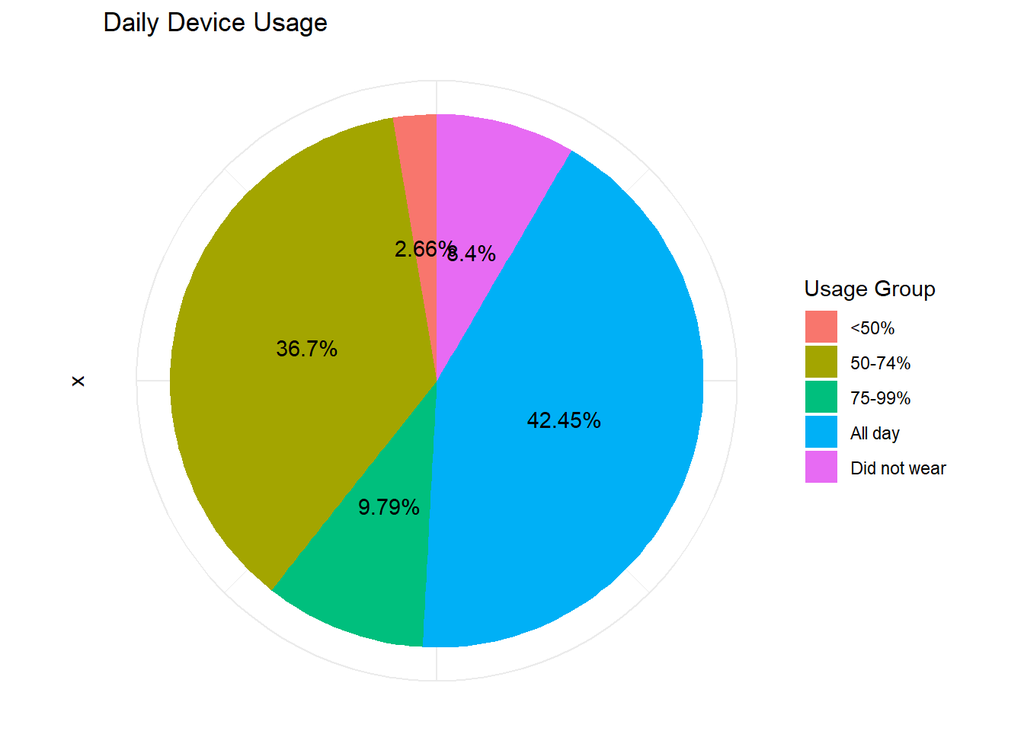

```r
usage_chart <- ggplot(usage_counts, aes(x = "", y = Percentage, fill = Usage_Group)) +
  geom_bar(width = 1, stat = "identity") +
  coord_polar("y", start = 0) +
  labs(title = "Daily Device Usage",
       fill = "Usage Group",
       y = NULL) +
  theme_minimal() +
  theme(axis.text.x = element_blank(),
        axis.ticks = element_blank(),
        legend.position = "right") +

  # Display percentage labels inside the pie slices
  geom_text(aes(label = paste0(round(Percentage, 2), "%")), position = position_stack(vjust = 0.5))

print(usage_chart)
```

Based on the chart we can see:

- Almost half of our users wore the device all day.
- A bit larger percentage take the device off at some point during the day.
- About 11% of the data shows very low daily engagement with the device.

**5.2 Activity days and times** We’re going to take a deeper look into when our users are active and if it differs by day.

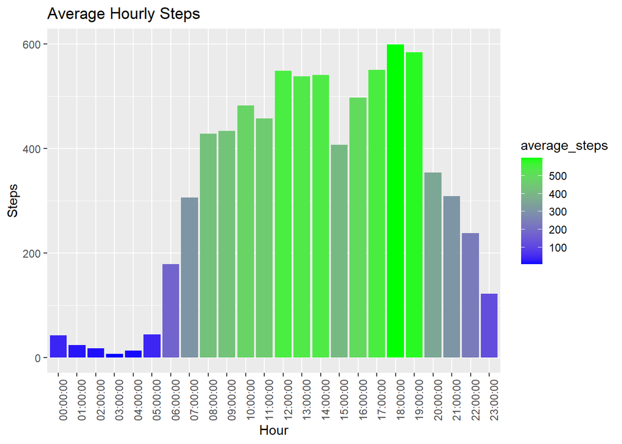

```r
hourly_steps %>%
  group_by(ActivityTime) %>%
  summarise(average_steps = mean(StepTotal)) %>%
  ggplot() +
  geom_col(mapping=aes(x=ActivityTime,y=average_steps,fill=average_steps))+
  labs(title="Average Hourly Steps",x="Hour",y="Steps")+
  scale_fill_gradient(low="blue",high="green")+
  theme(axis.text.x = element_text(angle = 90))
```

From this chart we can see:

- Users are most active between noon and 7pm.
- Activity peaks from 5pm-7pm.
- Activity quickly declines after 8pm and remains low into the early morning hours.

Let’s now look at steps by day.

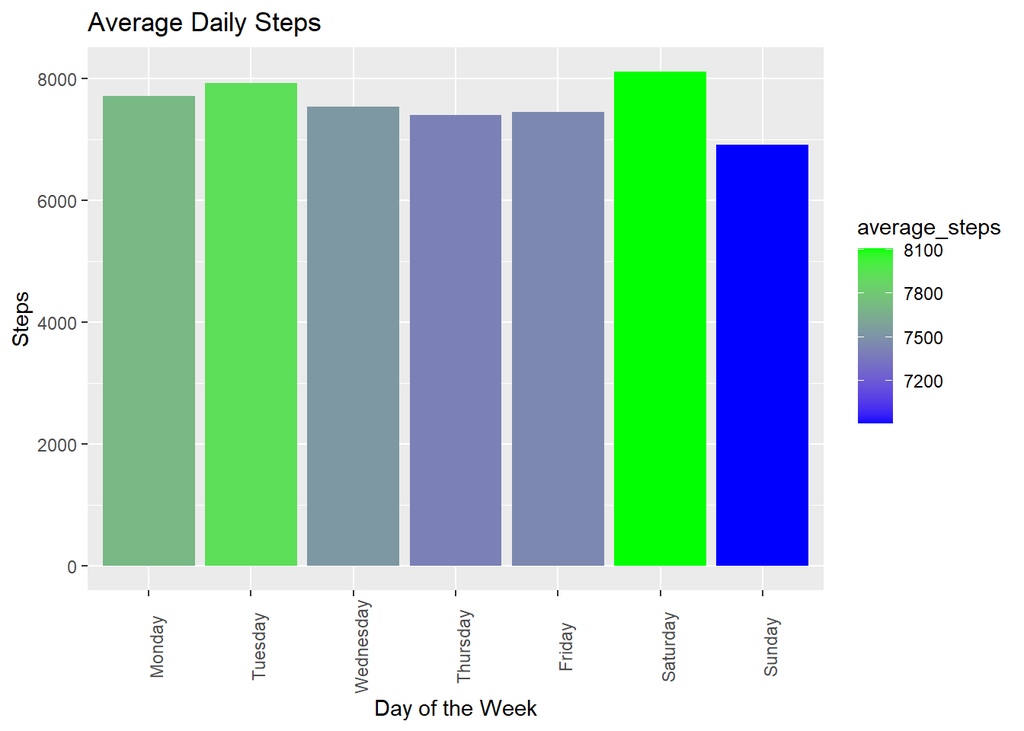

```r
day_order <- c("Monday", "Tuesday", "Wednesday", "Thursday", "Friday", "Saturday", "Sunday")

daily_activity %>%
  group_by(DayOfWeek) %>%
  summarise(average_steps = mean(TotalSteps)) %>%
  mutate(DayOfWeek = factor(DayOfWeek, levels = day_order)) %>%
  ggplot() +
  geom_col(mapping=aes(x=DayOfWeek,y=average_steps,fill=average_steps))+
  labs(title="Average Daily Steps",x="Day of the Week",y="Steps")+
  scale_fill_gradient(low="blue",high="green")+
  theme(axis.text.x = element_text(angle = 90))
```

From this chart we can see:

- Users are most active on Tuesday and Saturday
- Users are least active on Sundays

*Note:* There is not a large gap between any of these days. This may change with a larger data set.

**5.3 Activity intensity by hour and day**

For our final analysis, we’re going to look at intensity and how it relates to time and day.

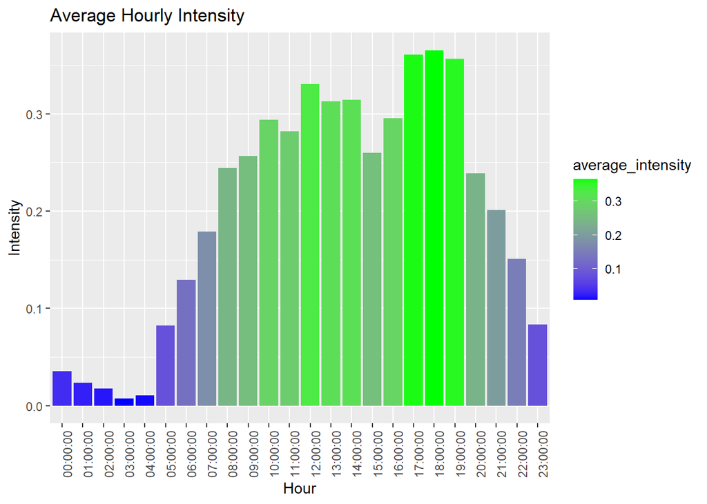

```r
hourly_steps_intensity %>%
  group_by(ActivityTime) %>%
  summarise(average_intensity = mean(AverageIntensity)) %>%
  ggplot() +
  geom_col(mapping=aes(x=ActivityTime,y=average_intensity,fill=average_intensity))+
  labs(title="Average Hourly Intensity",x="Hour",y="Intensity")+
  scale_fill_gradient(low="blue",high="green")+
  theme(axis.text.x = element_text(angle = 90))
```

From this chart we can see:

- Similar display to the hourly steps chart.
- However, there appears to be a more noticeable gap from 5pm-7pm when compared to the steps chart.

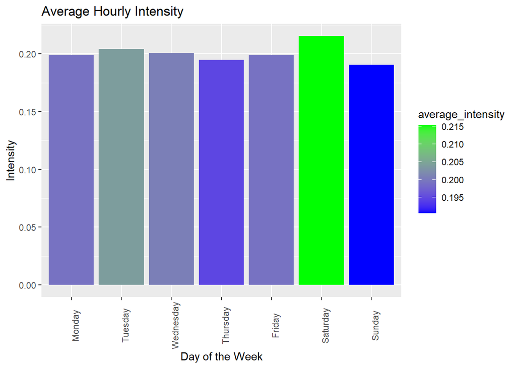

```r
hourly_steps_intensity %>%
  group_by(DayOfWeek) %>%
  summarise(average_intensity = mean(AverageIntensity)) %>%
  mutate(DayOfWeek = factor(DayOfWeek, levels = day_order)) %>%
  ggplot() +
  geom_col(mapping=aes(x=DayOfWeek,y=average_intensity,fill=average_intensity))+
  labs(title="Average Hourly Intensity",x="Day of the Week",y="Intensity")+
  scale_fill_gradient(low="blue",high="green")+
  theme(axis.text.x = element_text(angle = 90))
```

From this chart we can see:

- Similar display to the daily steps chart.
- While Tuesday and Saturday are still the highest two days, the difference is minimal.

## 6. Act Phase

Bellabeat has stated that their objective is to design technology that informs and inspires women around the world and empowers them with knowledge about their own health and habits. Knowing this, let’s go over some insights we’ve gained.

**1. Usability**

- Based on the data collected from these users, they did not use a lot of the functions provided.
- The weight and sleep functions did not have enough participation to be useful in analysis.
- **Recommendation** Bellabeat needs to make these features easy to use and stress the benefits of these features.

**2. Daily Usage**

- Bellabeats is selling a lifestyle product, but only 42% of FitBit users wear their device all day.
- **Recommendation** Bellabeat already focuses on style and comfort. This should be an advantage compared to others in the market. Stress this during marketing campaigns.

**3. Activity times**

- The data shows FitBit users are most active during the day and the hours following a typical 9am-5pm work day.
- Activity goes up briefly on Saturday which shows an active consumer base.
- **Recommendation** Advertisements focused on weekend activities or a busy home life may resonate with the target audience

*Note:* Demographic data was not available with this dataset. Further analysis would help solidify these recommendations.